# Predict Bike Sharing Demand with AutoGluon Template

## Project: Predict Bike Sharing Demand with AutoGluon

This notebook is a template with each step that you need to complete for the project.

Please fill in your code where there are explicit `?` markers in the notebook. You are welcome to add more cells and code as you see fit.

Once you have completed all the code implementations, please export your notebook as a HTML file so the reviews can view your code. Make sure you have all outputs correctly outputted.

`File-> Export Notebook As... -> Export Notebook as HTML`

There is a writeup to complete as well after all code implememtation is done. Please answer all questions and attach the necessary tables and charts. You can complete the writeup in either markdown or PDF.

Completing the code template and writeup template will cover all of the rubric points for this project.

The rubric contains "Stand Out Suggestions" for enhancing the project beyond the minimum requirements. The stand out suggestions are optional. If you decide to pursue the "stand out suggestions", you can include the code in this notebook and also discuss the results in the writeup file.

## Step 1: Create an account with Kaggle

### Create Kaggle Account and download API key

Below is example of steps to get the API username and key. Each student will have their own username and key.

1. Open account settings.

2. Scroll down to API and click Create New API Token.

3. Open up `kaggle.json` and use the username and key.


## Step 2: Download the Kaggle dataset using the kaggle python library

### Open up Sagemaker Studio and use starter template

1. Notebook should be using a `ml.t3.medium` instance (2 vCPU + 4 GiB)
2. Notebook should be using kernal: `Python 3 (MXNet 1.8 Python 3.7 CPU Optimized)`

### Install packages

```python
!pip install -U pip
!pip install -U setuptools wheel
!pip install -U "mxnet<2.0.0" bokeh==2.0.1
!pip install autogluon --no-cache-dir
# Without --no-cache-dir, smaller aws instances may have trouble installing
```

[output not shown]

[output cut: 99 more lines]

[output not shown]

```python
!pip install -U kaggle
```

[output not shown]

### Download and explore dataset

```python
# Download the dataset, it will be in a .zip file so you'll need to unzip it as well.
!kaggle competitions download -c bike-sharing-demand
# If you already downloaded it you can use the -o command to overwrite the file
!unzip -o bike-sharing-demand.zip
```

```
bike-sharing-demand.zip: Skipping, found more recently modified local copy (use --force to force download)
Archive:  bike-sharing-demand.zip
  inflating: sampleSubmission.csv
  inflating: test.csv
  inflating: train.csv
```

```python
import pandas as pd
from autogluon.tabular import TabularPredictor
import seaborn as sns
import matplotlib.pyplot as plt
```

```python
# Create the train dataset in pandas by reading the csv
# Set the parsing of the datetime column so you can use some of the `dt` features in pandas later
train = pd.read_csv('./data/train.csv', parse_dates = ['datetime'])
train.head()
```

|  | datetime | season | holiday | workingday | weather | temp | atemp | humidity | windspeed | casual | registered | count |
| --- | --- | --- | --- | --- | --- | --- | --- | --- | --- | --- | --- | --- |
| 0 | 2011-01-01 00:00:00 | 1 | 0 | 0 | 1 | 9.84 | 14.395 | 81 | 0.0 | 3 | 13 | 16 |
| 1 | 2011-01-01 01:00:00 | 1 | 0 | 0 | 1 | 9.02 | 13.635 | 80 | 0.0 | 8 | 32 | 40 |
| 2 | 2011-01-01 02:00:00 | 1 | 0 | 0 | 1 | 9.02 | 13.635 | 80 | 0.0 | 5 | 27 | 32 |
| 3 | 2011-01-01 03:00:00 | 1 | 0 | 0 | 1 | 9.84 | 14.395 | 75 | 0.0 | 3 | 10 | 13 |
| 4 | 2011-01-01 04:00:00 | 1 | 0 | 0 | 1 | 9.84 | 14.395 | 75 | 0.0 | 0 | 1 | 1 |

```python
# Simple output of the train dataset to view some of the min/max/varition of the dataset features.
train.describe()
```

|  | season | holiday | workingday | weather | temp | atemp | humidity | windspeed | casual | registered | count |
| --- | --- | --- | --- | --- | --- | --- | --- | --- | --- | --- | --- |
| count | 10886.000000 | 10886.000000 | 10886.000000 | 10886.000000 | 10886.00000 | 10886.000000 | 10886.000000 | 10886.000000 | 10886.000000 | 10886.000000 | 10886.000000 |
| mean | 2.506614 | 0.028569 | 0.680875 | 1.418427 | 20.23086 | 23.655084 | 61.886460 | 12.799395 | 36.021955 | 155.552177 | 191.574132 |
| std | 1.116174 | 0.166599 | 0.466159 | 0.633839 | 7.79159 | 8.474601 | 19.245033 | 8.164537 | 49.960477 | 151.039033 | 181.144454 |
| min | 1.000000 | 0.000000 | 0.000000 | 1.000000 | 0.82000 | 0.760000 | 0.000000 | 0.000000 | 0.000000 | 0.000000 | 1.000000 |
| 25% | 2.000000 | 0.000000 | 0.000000 | 1.000000 | 13.94000 | 16.665000 | 47.000000 | 7.001500 | 4.000000 | 36.000000 | 42.000000 |
| 50% | 3.000000 | 0.000000 | 1.000000 | 1.000000 | 20.50000 | 24.240000 | 62.000000 | 12.998000 | 17.000000 | 118.000000 | 145.000000 |
| 75% | 4.000000 | 0.000000 | 1.000000 | 2.000000 | 26.24000 | 31.060000 | 77.000000 | 16.997900 | 49.000000 | 222.000000 | 284.000000 |
| max | 4.000000 | 1.000000 | 1.000000 | 4.000000 | 41.00000 | 45.455000 | 100.000000 | 56.996900 | 367.000000 | 886.000000 | 977.000000 |

```python
# Create the test pandas dataframe in pandas by reading the csv, remember to parse the datetime!
test = pd.read_csv('./data/test.csv', parse_dates = ['datetime'])
test.head()
```

|  | datetime | season | holiday | workingday | weather | temp | atemp | humidity | windspeed |
| --- | --- | --- | --- | --- | --- | --- | --- | --- | --- |
| 0 | 2011-01-20 00:00:00 | 1 | 0 | 1 | 1 | 10.66 | 11.365 | 56 | 26.0027 |
| 1 | 2011-01-20 01:00:00 | 1 | 0 | 1 | 1 | 10.66 | 13.635 | 56 | 0.0000 |
| 2 | 2011-01-20 02:00:00 | 1 | 0 | 1 | 1 | 10.66 | 13.635 | 56 | 0.0000 |
| 3 | 2011-01-20 03:00:00 | 1 | 0 | 1 | 1 | 10.66 | 12.880 | 56 | 11.0014 |
| 4 | 2011-01-20 04:00:00 | 1 | 0 | 1 | 1 | 10.66 | 12.880 | 56 | 11.0014 |

```python
# Same thing as train and test dataset
submission = pd.read_csv('./data/sampleSubmission.csv')
submission.head()
```

|  | datetime | count |
| --- | --- | --- |
| 0 | 2011-01-20 00:00:00 | 0 |
| 1 | 2011-01-20 01:00:00 | 0 |
| 2 | 2011-01-20 02:00:00 | 0 |
| 3 | 2011-01-20 03:00:00 | 0 |
| 4 | 2011-01-20 04:00:00 | 0 |

## Step 3: Train a model using AutoGluon’s Tabular Prediction

Requirements:

- We are prediting `count`, so it is the label we are setting.
- Ignore `casual` and `registered` columns as they are also not present in the test dataset.
- Use the `root_mean_squared_error` as the metric to use for evaluation.
- Set a time limit of 10 minutes (600 seconds).
- Use the preset `best_quality` to focus on creating the best model.

```python
ignored_columns = ['casual', 'registered']
```

```python
predictor = TabularPredictor(
    label='count',
    eval_metric = 'root_mean_squared_error',
    path = 'AutogluonModels/train_0',
    learner_kwargs= {'ignored_columns': ignored_columns}
).fit(
    train_data=train,
    time_limit=600,
    presets='best_quality'
    )
```

```
Warning: path already exists! This predictor may overwrite an existing predictor! path="AutogluonModels/train_0"
Presets specified: ['best_quality']
Stack configuration (auto_stack=True): num_stack_levels=1, num_bag_folds=8, num_bag_sets=20
Beginning AutoGluon training ... Time limit = 600s
AutoGluon will save models to "AutogluonModels/train_0/"
AutoGluon Version:  0.6.1
Python Version:     3.8.10
Operating System:   Linux
Platform Machine:   x86_64
Platform Version:   #1 SMP Wed Oct 26 20:36:53 UTC 2022
Train Data Rows:    10886
Train Data Columns: 14
Label Column: count
Preprocessing data ...
AutoGluon infers your prediction problem is: 'regression' (because dtype of label-column == int and many unique label-values observed).
	Label info (max, min, mean, stddev): (977, 1, 191.57413, 181.14445)
	If 'regression' is not the correct problem_type, please manually specify the problem_type parameter during predictor init (You may specify problem_type as one of: ['binary', 'multiclass', 'regression'])
Using Feature Generators to preprocess the data ...
Dropping user-specified ignored columns: ['casual', 'registered']
Fitting AutoMLPipelineFeatureGenerator...
	Available Memory:                    1017.43 MB
	Train Data (Original)  Memory Usage: 1.66 MB (0.2% of available memory)
	Inferring data type of each feature based on column values. Set feature_metadata_in to manually specify special dtypes of the features.
	Stage 1 Generators:
		Fitting AsTypeFeatureGenerator...
			Note: Converting 2 features to boolean dtype as they only contain 2 unique values.
	Stage 2 Generators:
		Fitting FillNaFeatureGenerator...
	Stage 3 Generators:
		Fitting IdentityFeatureGenerator...
		Fitting CategoryFeatureGenerator...
			Fitting CategoryMemoryMinimizeFeatureGenerator...
		Fitting DatetimeFeatureGenerator...
/usr/local/lib/python3.8/dist-packages/autogluon/features/generators/datetime.py:59: FutureWarning: casting datetime64[ns, UTC] values to int64 with .astype(...) is deprecated and will raise in a future version. Use .view(...) instead.
  good_rows = series[~series.isin(bad_rows)].astype(np.int64)
	Stage 4 Generators:
		Fitting DropUniqueFeatureGenerator...
	Types of features in original data (raw dtype, special dtypes):
		('datetime', []) : 1 | ['datetime']
		('float', [])    : 3 | ['temp', 'atemp', 'windspeed']
```

[output cut: 82 more lines]

```
	Warning: Reducing model 'n_estimators' from 300 -> 121 due to low memory. Expected memory usage reduced from 37.04% -> 15.0% of available memory...
	-31.7339	 = Validation score   (-root_mean_squared_error)
	3.94s	 = Training   runtime
	0.4s	 = Validation runtime
Fitting model: NeuralNetFastAI_BAG_L2 ... Training model for up to 0.47s of the 0.45s of remaining time.
	Fitting 8 child models (S1F1 - S1F8) | Fitting with ParallelLocalFoldFittingStrategy
	Time limit exceeded... Skipping NeuralNetFastAI_BAG_L2.
2023-01-05 23:21:17,677	ERROR worker.py:399 -- Unhandled error (suppress with 'RAY_IGNORE_UNHANDLED_ERRORS=1'): The worker died unexpectedly while executing this task. Check python-core-worker-*.log files for more information.
Completed 1/20 k-fold bagging repeats ...
Fitting model: WeightedEnsemble_L3 ... Training model for up to 360.0s of the -6.39s of remaining time.
	-30.1607	 = Validation score   (-root_mean_squared_error)
	0.31s	 = Training   runtime
	0.0s	 = Validation runtime
AutoGluon training complete, total runtime = 606.92s ... Best model: "WeightedEnsemble_L3"
TabularPredictor saved. To load, use: predictor = TabularPredictor.load("AutogluonModels/train_0/")
```

### Review AutoGluon's training run with ranking of models that did the best.

```python
summary = predictor.fit_summary(show_plot=True)
```

[output not shown]

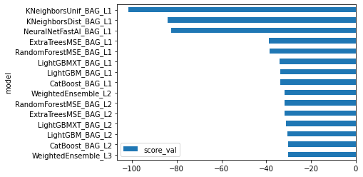

```python
predictor.leaderboard(silent=True).plot(kind="barh", x="model", y="score_val")
```

### Create predictions from test dataset

```python
predictions = predictor.predict(test).to_frame()
```

```python
predictions.head()
```

|  | count |
| --- | --- |
| 0 | 23.745392 |
| 1 | 41.830887 |
| 2 | 45.173424 |
| 3 | 47.954044 |
| 4 | 50.830311 |

```python
test.join(predictions)[["datetime", "count"]]
```

|  | datetime | count |
| --- | --- | --- |
| 0 | 2011-01-20 00:00:00 | 23.745392 |
| 1 | 2011-01-20 01:00:00 | 41.830887 |
| 2 | 2011-01-20 02:00:00 | 45.173424 |
| 3 | 2011-01-20 03:00:00 | 47.954044 |
| 4 | 2011-01-20 04:00:00 | 50.830311 |
| ... | ... | ... |
| 6488 | 2012-12-31 19:00:00 | 161.012787 |
| 6489 | 2012-12-31 20:00:00 | 161.054199 |
| 6490 | 2012-12-31 21:00:00 | 153.429443 |
| 6491 | 2012-12-31 22:00:00 | 150.891861 |
| 6492 | 2012-12-31 23:00:00 | 149.414185 |

6493 rows × 2 columns

#### NOTE: Kaggle will reject the submission if we don't set everything to be > 0.

```python
# Describe the `predictions` series to see if there are any negative values
predictions.describe()
```

|  | count |
| --- | --- |
| count | 6493.000000 |
| mean | 100.855415 |
| std | 90.165398 |
| min | 2.947044 |
| 25% | 20.590580 |
| 50% | 63.036968 |
| 75% | 169.972000 |
| max | 362.804230 |

```python
# How many negative values do we have?
predictions.info()
# negative_count = (predictions < 0).sum()
# negative_count
```

```
<class 'pandas.core.frame.DataFrame'>
RangeIndex: 6493 entries, 0 to 6492
Data columns (total 1 columns):
 #   Column  Non-Null Count  Dtype
---  ------  --------------  -----
 0   count   6493 non-null   float32
dtypes: float32(1)
memory usage: 25.5 KB
```

```python
# Set them to zero
predictions.clip(lower=0)
predictions.head()
```

[output not shown]

### Set predictions to submission dataframe, save, and submit

```python
submission["count"] = predictions
submission.to_csv("submission.csv", index=False)
```

```python
!kaggle competitions submit -c bike-sharing-demand -f submission.csv -m "first raw submission"
```

```
Successfully submitted to Bike Sharing Demand
```

#### View submission via the command line or in the web browser under the competition's page - `My Submissions`

```python
!kaggle competitions submissions -c bike-sharing-demand | tail -n +1 | head -n 8
```

[output not shown]

#### Initial score of `1.80206`

## Step 4: Exploratory Data Analysis and Creating an additional feature

- Any additional feature will do, but a great suggestion would be to separate out the datetime into hour, day, or month parts.

```
array([[<AxesSubplot:title={'center':'datetime'}>,
        <AxesSubplot:title={'center':'season'}>,
        <AxesSubplot:title={'center':'holiday'}>],
       [<AxesSubplot:title={'center':'workingday'}>,
        <AxesSubplot:title={'center':'weather'}>,
        <AxesSubplot:title={'center':'temp'}>],
       [<AxesSubplot:title={'center':'atemp'}>,
        <AxesSubplot:title={'center':'humidity'}>,
        <AxesSubplot:title={'center':'windspeed'}>],
       [<AxesSubplot:title={'center':'casual'}>,
        <AxesSubplot:title={'center':'registered'}>,
        <AxesSubplot:title={'center':'count'}>]], dtype=object)
```

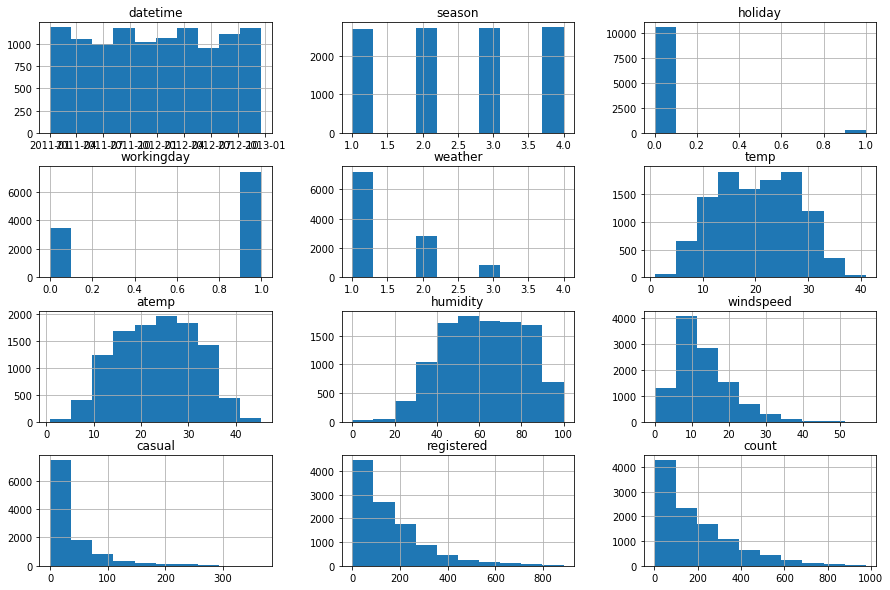

```python
# Create a histogram of all features to show the distribution of each one relative to the data. This is part of the exploritory data analysis
train.hist(figsize=(15,10))
```

```python
corr = train.corr()
corr
```

|  | season | holiday | workingday | weather | temp | atemp | humidity | windspeed | casual | registered | count |
| --- | --- | --- | --- | --- | --- | --- | --- | --- | --- | --- | --- |
| season | 1.000000 | 0.029368 | -0.008126 | 0.008879 | 0.258689 | 0.264744 | 0.190610 | -0.147121 | 0.096758 | 0.164011 | 0.163439 |
| holiday | 0.029368 | 1.000000 | -0.250491 | -0.007074 | 0.000295 | -0.005215 | 0.001929 | 0.008409 | 0.043799 | -0.020956 | -0.005393 |
| workingday | -0.008126 | -0.250491 | 1.000000 | 0.033772 | 0.029966 | 0.024660 | -0.010880 | 0.013373 | -0.319111 | 0.119460 | 0.011594 |
| weather | 0.008879 | -0.007074 | 0.033772 | 1.000000 | -0.055035 | -0.055376 | 0.406244 | 0.007261 | -0.135918 | -0.109340 | -0.128655 |
| temp | 0.258689 | 0.000295 | 0.029966 | -0.055035 | 1.000000 | 0.984948 | -0.064949 | -0.017852 | 0.467097 | 0.318571 | 0.394454 |
| atemp | 0.264744 | -0.005215 | 0.024660 | -0.055376 | 0.984948 | 1.000000 | -0.043536 | -0.057473 | 0.462067 | 0.314635 | 0.389784 |
| humidity | 0.190610 | 0.001929 | -0.010880 | 0.406244 | -0.064949 | -0.043536 | 1.000000 | -0.318607 | -0.348187 | -0.265458 | -0.317371 |
| windspeed | -0.147121 | 0.008409 | 0.013373 | 0.007261 | -0.017852 | -0.057473 | -0.318607 | 1.000000 | 0.092276 | 0.091052 | 0.101369 |
| casual | 0.096758 | 0.043799 | -0.319111 | -0.135918 | 0.467097 | 0.462067 | -0.348187 | 0.092276 | 1.000000 | 0.497250 | 0.690414 |
| registered | 0.164011 | -0.020956 | 0.119460 | -0.109340 | 0.318571 | 0.314635 | -0.265458 | 0.091052 | 0.497250 | 1.000000 | 0.970948 |
| count | 0.163439 | -0.005393 | 0.011594 | -0.128655 | 0.394454 | 0.389784 | -0.317371 | 0.101369 | 0.690414 | 0.970948 | 1.000000 |

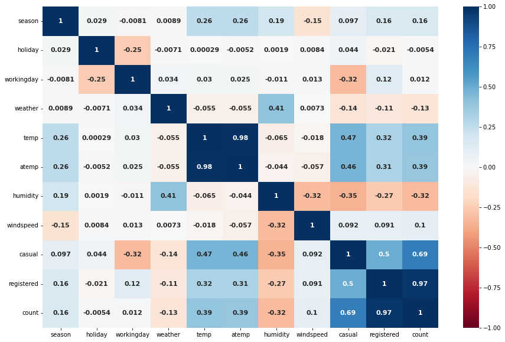

```python
fig, ax = plt.subplots(figsize=(15,10))
sns.heatmap(corr,  cmap='RdBu', vmin=-1, vmax=1, annot=True,
           annot_kws={'fontsize':11, 'fontweight':'bold'})
```

```python
# create a new feature train data

train['Month']=  pd.to_datetime(train['datetime']).dt.month
train['Day'] = pd.to_datetime(train['datetime']).dt.day_name()
train['Hour'] = pd.to_datetime(train['datetime']).dt.hour
```

```python
train_data = pd.get_dummies(train, columns = ['Day'])
```

```python
# create a new feature test data

test['Month']=  pd.to_datetime(test['datetime']).dt.month
test['Day'] = pd.to_datetime(test['datetime']).dt.day_name()
test['Hour'] = pd.to_datetime(test['datetime']).dt.hour
```

```python
test_data = pd.get_dummies(test, columns = ['Day'])
```

```python
train_data
```

|  | datetime | season | holiday | workingday | weather | temp | atemp | humidity | windspeed | casual | ... | count | Month | Hour | Day_Friday | Day_Monday | Day_Saturday | Day_Sunday | Day_Thursday | Day_Tuesday | Day_Wednesday |
| --- | --- | --- | --- | --- | --- | --- | --- | --- | --- | --- | --- | --- | --- | --- | --- | --- | --- | --- | --- | --- | --- |
| 0 | 2011-01-01 00:00:00 | 1 | 0 | 0 | 1 | 9.84 | 14.395 | 81 | 0.0000 | 3 | ... | 16 | 1 | 0 | 0 | 0 | 1 | 0 | 0 | 0 | 0 |
| 1 | 2011-01-01 01:00:00 | 1 | 0 | 0 | 1 | 9.02 | 13.635 | 80 | 0.0000 | 8 | ... | 40 | 1 | 1 | 0 | 0 | 1 | 0 | 0 | 0 | 0 |
| 2 | 2011-01-01 02:00:00 | 1 | 0 | 0 | 1 | 9.02 | 13.635 | 80 | 0.0000 | 5 | ... | 32 | 1 | 2 | 0 | 0 | 1 | 0 | 0 | 0 | 0 |
| 3 | 2011-01-01 03:00:00 | 1 | 0 | 0 | 1 | 9.84 | 14.395 | 75 | 0.0000 | 3 | ... | 13 | 1 | 3 | 0 | 0 | 1 | 0 | 0 | 0 | 0 |
| 4 | 2011-01-01 04:00:00 | 1 | 0 | 0 | 1 | 9.84 | 14.395 | 75 | 0.0000 | 0 | ... | 1 | 1 | 4 | 0 | 0 | 1 | 0 | 0 | 0 | 0 |
| ... | ... | ... | ... | ... | ... | ... | ... | ... | ... | ... | ... | ... | ... | ... | ... | ... | ... | ... | ... | ... | ... |
| 10881 | 2012-12-19 19:00:00 | 4 | 0 | 1 | 1 | 15.58 | 19.695 | 50 | 26.0027 | 7 | ... | 336 | 12 | 19 | 0 | 0 | 0 | 0 | 0 | 0 | 1 |
| 10882 | 2012-12-19 20:00:00 | 4 | 0 | 1 | 1 | 14.76 | 17.425 | 57 | 15.0013 | 10 | ... | 241 | 12 | 20 | 0 | 0 | 0 | 0 | 0 | 0 | 1 |
| 10883 | 2012-12-19 21:00:00 | 4 | 0 | 1 | 1 | 13.94 | 15.910 | 61 | 15.0013 | 4 | ... | 168 | 12 | 21 | 0 | 0 | 0 | 0 | 0 | 0 | 1 |
| 10884 | 2012-12-19 22:00:00 | 4 | 0 | 1 | 1 | 13.94 | 17.425 | 61 | 6.0032 | 12 | ... | 129 | 12 | 22 | 0 | 0 | 0 | 0 | 0 | 0 | 1 |
| 10885 | 2012-12-19 23:00:00 | 4 | 0 | 1 | 1 | 13.12 | 16.665 | 66 | 8.9981 | 4 | ... | 88 | 12 | 23 | 0 | 0 | 0 | 0 | 0 | 0 | 1 |

10886 rows × 21 columns

## Make category types for these so models know they are not just numbers

- AutoGluon originally sees these as ints, but in reality they are int representations of a category.
- Setting the dtype to category will classify these as categories in AutoGluon.

```python
train_data["season"] = train_data["season"].astype("category")
train_data["weather"] = train_data["weather"].astype("category")
test_data["season"] = test_data["season"].astype("category")
test_data["weather"] = test_data["weather"].astype("category")
```

```python
# View are new feature
train_data.head()
```

|  | datetime | season | holiday | workingday | weather | temp | atemp | humidity | windspeed | casual | ... | count | Month | Hour | Day_Friday | Day_Monday | Day_Saturday | Day_Sunday | Day_Thursday | Day_Tuesday | Day_Wednesday |
| --- | --- | --- | --- | --- | --- | --- | --- | --- | --- | --- | --- | --- | --- | --- | --- | --- | --- | --- | --- | --- | --- |
| 0 | 2011-01-01 00:00:00 | 1 | 0 | 0 | 1 | 9.84 | 14.395 | 81 | 0.0 | 3 | ... | 16 | 1 | 0 | 0 | 0 | 1 | 0 | 0 | 0 | 0 |
| 1 | 2011-01-01 01:00:00 | 1 | 0 | 0 | 1 | 9.02 | 13.635 | 80 | 0.0 | 8 | ... | 40 | 1 | 1 | 0 | 0 | 1 | 0 | 0 | 0 | 0 |
| 2 | 2011-01-01 02:00:00 | 1 | 0 | 0 | 1 | 9.02 | 13.635 | 80 | 0.0 | 5 | ... | 32 | 1 | 2 | 0 | 0 | 1 | 0 | 0 | 0 | 0 |
| 3 | 2011-01-01 03:00:00 | 1 | 0 | 0 | 1 | 9.84 | 14.395 | 75 | 0.0 | 3 | ... | 13 | 1 | 3 | 0 | 0 | 1 | 0 | 0 | 0 | 0 |
| 4 | 2011-01-01 04:00:00 | 1 | 0 | 0 | 1 | 9.84 | 14.395 | 75 | 0.0 | 0 | ... | 1 | 1 | 4 | 0 | 0 | 1 | 0 | 0 | 0 | 0 |

5 rows × 21 columns

```
array([[<AxesSubplot:title={'center':'datetime'}>,
        <AxesSubplot:title={'center':'holiday'}>,
        <AxesSubplot:title={'center':'workingday'}>,
        <AxesSubplot:title={'center':'temp'}>],
       [<AxesSubplot:title={'center':'atemp'}>,
        <AxesSubplot:title={'center':'humidity'}>,
        <AxesSubplot:title={'center':'windspeed'}>,
        <AxesSubplot:title={'center':'casual'}>],
       [<AxesSubplot:title={'center':'registered'}>,
        <AxesSubplot:title={'center':'count'}>,
        <AxesSubplot:title={'center':'Month'}>,
        <AxesSubplot:title={'center':'Hour'}>],
       [<AxesSubplot:title={'center':'Day_Friday'}>,
        <AxesSubplot:title={'center':'Day_Monday'}>,
        <AxesSubplot:title={'center':'Day_Saturday'}>,
        <AxesSubplot:title={'center':'Day_Sunday'}>],
       [<AxesSubplot:title={'center':'Day_Thursday'}>,
        <AxesSubplot:title={'center':'Day_Tuesday'}>,
        <AxesSubplot:title={'center':'Day_Wednesday'}>, <AxesSubplot:>]],
      dtype=object)
```

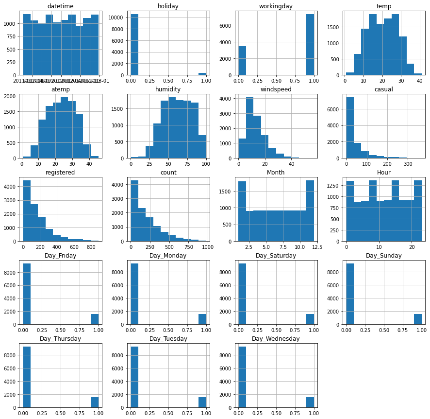

```python
# View histogram of all features again now with the hour feature
train_data.hist(figsize=(15,15))
```

## Step 5: Rerun the model with the same settings as before, just with more features

```python
predictor_new_features = TabularPredictor(
    label='count',
    eval_metric = 'root_mean_squared_error',
    path = 'AutogluonModels/train_new_feature',
    learner_kwargs= {'ignored_columns': ignored_columns}
).fit(
    train_data=train_data,
    time_limit=600,
    presets='best_quality'
    )
```

```
Warning: path already exists! This predictor may overwrite an existing predictor! path="AutogluonModels/train_new_feature"
Presets specified: ['best_quality']
Stack configuration (auto_stack=True): num_stack_levels=1, num_bag_folds=8, num_bag_sets=20
Beginning AutoGluon training ... Time limit = 600s
AutoGluon will save models to "AutogluonModels/train_new_feature/"
AutoGluon Version:  0.6.1
Python Version:     3.8.10
Operating System:   Linux
Platform Machine:   x86_64
Platform Version:   #1 SMP Wed Oct 26 20:36:53 UTC 2022
Train Data Rows:    10886
Train Data Columns: 20
Label Column: count
Preprocessing data ...
AutoGluon infers your prediction problem is: 'regression' (because dtype of label-column == int and many unique label-values observed).
	Label info (max, min, mean, stddev): (977, 1, 191.57413, 181.14445)
	If 'regression' is not the correct problem_type, please manually specify the problem_type parameter during predictor init (You may specify problem_type as one of: ['binary', 'multiclass', 'regression'])
Using Feature Generators to preprocess the data ...
Dropping user-specified ignored columns: ['casual', 'registered']
Fitting AutoMLPipelineFeatureGenerator...
	Available Memory:                    3008.53 MB
	Train Data (Original)  Memory Usage: 0.88 MB (0.0% of available memory)
	Inferring data type of each feature based on column values. Set feature_metadata_in to manually specify special dtypes of the features.
	Stage 1 Generators:
		Fitting AsTypeFeatureGenerator...
			Note: Converting 9 features to boolean dtype as they only contain 2 unique values.
	Stage 2 Generators:
		Fitting FillNaFeatureGenerator...
	Stage 3 Generators:
		Fitting IdentityFeatureGenerator...
		Fitting CategoryFeatureGenerator...
			Fitting CategoryMemoryMinimizeFeatureGenerator...
		Fitting DatetimeFeatureGenerator...
/usr/local/lib/python3.8/dist-packages/autogluon/features/generators/datetime.py:59: FutureWarning: casting datetime64[ns, UTC] values to int64 with .astype(...) is deprecated and will raise in a future version. Use .view(...) instead.
  good_rows = series[~series.isin(bad_rows)].astype(np.int64)
	Stage 4 Generators:
		Fitting DropUniqueFeatureGenerator...
	Types of features in original data (raw dtype, special dtypes):
		('category', []) :  2 | ['season', 'weather']
		('datetime', []) :  1 | ['datetime']
```

[output cut: 74 more lines]

```
	Fitting 8 child models (S1F1 - S1F8) | Fitting with ParallelLocalFoldFittingStrategy
	-30.417	 = Validation score   (-root_mean_squared_error)
	83.25s	 = Training   runtime
	0.11s	 = Validation runtime
Fitting model: ExtraTreesMSE_BAG_L2 ... Training model for up to 4.29s of the 4.28s of remaining time.
	-31.5647	 = Validation score   (-root_mean_squared_error)
	10.07s	 = Training   runtime
	0.64s	 = Validation runtime
Completed 1/20 k-fold bagging repeats ...
Fitting model: WeightedEnsemble_L3 ... Training model for up to 360.0s of the -9.24s of remaining time.
	-30.2317	 = Validation score   (-root_mean_squared_error)
	0.32s	 = Training   runtime
	0.0s	 = Validation runtime
AutoGluon training complete, total runtime = 609.8s ... Best model: "WeightedEnsemble_L3"
TabularPredictor saved. To load, use: predictor = TabularPredictor.load("AutogluonModels/train_new_feature/")
```

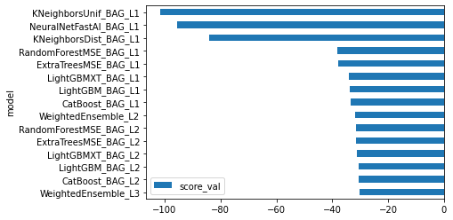

```python
predictor_new_features.leaderboard(silent=True).plot(kind="barh", x="model", y="score_val")
```

```python
summary = predictor_new_features.fit_summary(show_plot=True)
```

```
*** Summary of fit() ***
Estimated performance of each model:
                     model   score_val  pred_time_val    fit_time  pred_time_val_marginal  fit_time_marginal  stack_level  can_infer  fit_order
0      WeightedEnsemble_L3  -30.231664      15.028273  549.659988                0.001015           0.323084            3       True         15
1          CatBoost_BAG_L2  -30.417046      13.431463  471.476704                0.106957          83.252877            2       True         13
2          LightGBM_BAG_L2  -30.674154      13.603639  410.361189                0.279134          22.137362            2       True         11
3        LightGBMXT_BAG_L2  -31.316468      13.987501  413.030656                0.662996          24.806829            2       True         10
4     ExtraTreesMSE_BAG_L2  -31.564747      13.967277  398.295393                0.642771          10.071566            2       True         14
5   RandomForestMSE_BAG_L2  -31.586674      13.978172  419.139835                0.653666          30.916008            2       True         12
6      WeightedEnsemble_L2  -31.947208      12.843833  347.351412                0.000768           0.418854            2       True          9
7          CatBoost_BAG_L1  -33.536514       0.139576  214.367590                0.139576         214.367590            1       True          6
8          LightGBM_BAG_L1  -33.713699       3.589912   41.902025                3.589912          41.902025            1       True          4
9        LightGBMXT_BAG_L1  -34.148450       7.950131   70.258034                7.950131          70.258034            1       True          3
10    ExtraTreesMSE_BAG_L1  -37.756465       0.550741    6.779788                0.550741           6.779788            1       True          7
11  RandomForestMSE_BAG_L1  -38.199344       0.574471   13.594655                0.574471          13.594655            1       True          5
12   KNeighborsDist_BAG_L1  -84.125061       0.038234    0.030465                0.038234           0.030465            1       True          2
13  NeuralNetFastAI_BAG_L1  -95.681551       0.439042   41.258169                0.439042          41.258169            1       True          8
14   KNeighborsUnif_BAG_L1 -101.546199       0.042399    0.033099                0.042399           0.033099            1       True          1
Number of models trained: 15
Types of models trained:
{'StackerEnsembleModel_NNFastAiTabular', 'StackerEnsembleModel_KNN', 'StackerEnsembleModel_LGB', 'WeightedEnsembleModel', 'StackerEnsembleModel_CatBoost', 'StackerEnsembleModel_RF', 'StackerEnsembleModel_XT'}
Bagging used: True  (with 8 folds)
Multi-layer stack-ensembling used: True  (with 3 levels)
Feature Metadata (Processed):
(raw dtype, special dtypes):
('category', [])             : 2 | ['season', 'weather']
('float', [])                : 3 | ['temp', 'atemp', 'windspeed']
('int', [])                  : 3 | ['humidity', 'Month', 'Hour']
('int', ['bool'])            : 9 | ['holiday', 'workingday', 'Day_Friday', 'Day_Monday', 'Day_Saturday', ...]
('int', ['datetime_as_int']) : 5 | ['datetime', 'datetime.year', 'datetime.month', 'datetime.day', 'datetime.dayofweek']
Plot summary of models saved to file: AutogluonModels/train_new_feature/SummaryOfModels.html
*** End of fit() summary ***
```

```python
summary.keys()
```

```
dict_keys(['model_types', 'model_performance', 'model_best', 'model_paths', 'model_fit_times', 'model_pred_times', 'num_bag_folds', 'max_stack_level', 'model_hyperparams', 'leaderboard'])
```

```python
summary['model_best']
```

```
'WeightedEnsemble_L3'
```

```python
summary['model_types']
```

```
{'KNeighborsUnif_BAG_L1': 'StackerEnsembleModel_KNN',
 'KNeighborsDist_BAG_L1': 'StackerEnsembleModel_KNN',
 'LightGBMXT_BAG_L1': 'StackerEnsembleModel_LGB',
 'LightGBM_BAG_L1': 'StackerEnsembleModel_LGB',
 'RandomForestMSE_BAG_L1': 'StackerEnsembleModel_RF',
 'CatBoost_BAG_L1': 'StackerEnsembleModel_CatBoost',
 'ExtraTreesMSE_BAG_L1': 'StackerEnsembleModel_XT',
 'NeuralNetFastAI_BAG_L1': 'StackerEnsembleModel_NNFastAiTabular',
 'WeightedEnsemble_L2': 'WeightedEnsembleModel',
 'LightGBMXT_BAG_L2': 'StackerEnsembleModel_LGB',
 'LightGBM_BAG_L2': 'StackerEnsembleModel_LGB',
 'RandomForestMSE_BAG_L2': 'StackerEnsembleModel_RF',
 'CatBoost_BAG_L2': 'StackerEnsembleModel_CatBoost',
 'ExtraTreesMSE_BAG_L2': 'StackerEnsembleModel_XT',
 'WeightedEnsemble_L3': 'WeightedEnsembleModel'}
```

```python
summary['model_hyperparams']['WeightedEnsemble_L3']
```

```
{'use_orig_features': False,
 'max_base_models': 25,
 'max_base_models_per_type': 5,
 'save_bag_folds': True}
```

```python
summary['model_performance']['WeightedEnsemble_L3']
```

[output not shown]

```python
predictions_new_features = predictor_new_features.predict(test_data).to_frame()
```

```python
test_data.join(predictions_new_features)[["datetime", "count"]]
```

|  | datetime | count |
| --- | --- | --- |
| 0 | 2011-01-20 00:00:00 | 16.983265 |
| 1 | 2011-01-20 01:00:00 | 11.353883 |
| 2 | 2011-01-20 02:00:00 | 10.860777 |
| 3 | 2011-01-20 03:00:00 | 9.054020 |
| 4 | 2011-01-20 04:00:00 | 7.520559 |
| ... | ... | ... |
| 6488 | 2012-12-31 19:00:00 | 296.126221 |
| 6489 | 2012-12-31 20:00:00 | 211.099442 |
| 6490 | 2012-12-31 21:00:00 | 153.173691 |
| 6491 | 2012-12-31 22:00:00 | 112.595642 |
| 6492 | 2012-12-31 23:00:00 | 72.684250 |

6493 rows × 2 columns

```python
# Remember to set all negative values to zero
predictions_new_features.info()
```

```
<class 'pandas.core.frame.DataFrame'>
RangeIndex: 6493 entries, 0 to 6492
Data columns (total 1 columns):
 #   Column  Non-Null Count  Dtype
---  ------  --------------  -----
 0   count   6493 non-null   float32
dtypes: float32(1)
memory usage: 25.5 KB
```

```python
# Same submitting predictions
submission["count"] = predictions_new_features
submission.to_csv("submission_new_features.csv", index=False)
```

```python
!kaggle competitions submit -c bike-sharing-demand -f submission_new_features.csv -m "new features"
```

```
Successfully submitted to Bike Sharing Demand
```

```python
!kaggle competitions submissions -c bike-sharing-demand | tail -n +1 | head -n 6
```

```
fileName                     date                 description           status    publicScore  privateScore
---------------------------  -------------------  --------------------  --------  -----------  ------------
submission_new_features.csv  2023-01-04 19:08:08  new features          complete  0.71316      0.71316
submission.csv               2023-01-03 23:41:09  first raw submission  complete  1.80206      1.80206
```

#### New Score of `0.71316`

## Step 6: Hyper parameter optimization

- There are many options for hyper parameter optimization.
- Options are to change the AutoGluon higher level parameters or the individual model hyperparameters.
- The hyperparameters of the models themselves that are in AutoGluon. Those need the `hyperparameter` and `hyperparameter_tune_kwargs` arguments.

```python
# Change AutoGluon higher level parametrs - 1st try
predictor_new_hpo = TabularPredictor(
    label='count',
    eval_metric = 'root_mean_squared_error',
    path = 'AutogluonModels/train_new_hpo',
    learner_kwargs= {'ignored_columns': ignored_columns}
).fit(
    train_data=train_data,
    time_limit=900,
    presets='good_quality'
    )
```

```
Warning: path already exists! This predictor may overwrite an existing predictor! path="AutogluonModels/train_new_hpo"
Presets specified: ['good_quality']
Stack configuration (auto_stack=True): num_stack_levels=1, num_bag_folds=8, num_bag_sets=20
Beginning AutoGluon training ... Time limit = 900s
AutoGluon will save models to "AutogluonModels/train_new_hpo/"
AutoGluon Version:  0.6.1
Python Version:     3.8.10
Operating System:   Linux
Platform Machine:   x86_64
Platform Version:   #1 SMP Wed Oct 26 20:36:53 UTC 2022
Train Data Rows:    10886
Train Data Columns: 20
Label Column: count
Preprocessing data ...
AutoGluon infers your prediction problem is: 'regression' (because dtype of label-column == int and many unique label-values observed).
	Label info (max, min, mean, stddev): (977, 1, 191.57413, 181.14445)
	If 'regression' is not the correct problem_type, please manually specify the problem_type parameter during predictor init (You may specify problem_type as one of: ['binary', 'multiclass', 'regression'])
Using Feature Generators to preprocess the data ...
Dropping user-specified ignored columns: ['casual', 'registered']
Fitting AutoMLPipelineFeatureGenerator...
	Available Memory:                    3010.91 MB
	Train Data (Original)  Memory Usage: 0.88 MB (0.0% of available memory)
	Inferring data type of each feature based on column values. Set feature_metadata_in to manually specify special dtypes of the features.
	Stage 1 Generators:
		Fitting AsTypeFeatureGenerator...
			Note: Converting 9 features to boolean dtype as they only contain 2 unique values.
	Stage 2 Generators:
		Fitting FillNaFeatureGenerator...
	Stage 3 Generators:
		Fitting IdentityFeatureGenerator...
		Fitting CategoryFeatureGenerator...
			Fitting CategoryMemoryMinimizeFeatureGenerator...
		Fitting DatetimeFeatureGenerator...
/usr/local/lib/python3.8/dist-packages/autogluon/features/generators/datetime.py:59: FutureWarning: casting datetime64[ns, UTC] values to int64 with .astype(...) is deprecated and will raise in a future version. Use .view(...) instead.
  good_rows = series[~series.isin(bad_rows)].astype(np.int64)
	Stage 4 Generators:
		Fitting DropUniqueFeatureGenerator...
	Types of features in original data (raw dtype, special dtypes):
		('category', []) :  2 | ['season', 'weather']
		('datetime', []) :  1 | ['datetime']
```

[output cut: 133 more lines]

```
	6.67s	 = Training   runtime
	0.47s	 = Validation runtime
Fitting 1 L2 models ...
Fitting model: NeuralNetFastAI_BAG_L2_FULL ...
	Stopping at the best epoch learned earlier - 25.
	9.89s	 = Training   runtime
Fitting 1 L2 models ...
Fitting model: XGBoost_BAG_L2_FULL ...
	0.23s	 = Training   runtime
Fitting 1 L2 models ...
Fitting model: LightGBMLarge_BAG_L2_FULL ...
	1.02s	 = Training   runtime
Fitting model: WeightedEnsemble_L3_FULL | Skipping fit via cloning parent ...
	0.47s	 = Training   runtime
TabularPredictor saved. To load, use: predictor = TabularPredictor.load("AutogluonModels/train_new_hpo/")
```

```python
predictor_new_hpo.fit_summary(show_plot=True)
```

```
*** Summary of fit() ***
Estimated performance of each model:
                          model  score_val  pred_time_val    fit_time  pred_time_val_marginal  fit_time_marginal  stack_level  can_infer  fit_order
0           WeightedEnsemble_L3 -31.888814      16.994981  753.434120                0.000992           0.466967            3      False         16
1           WeightedEnsemble_L2 -31.929342      14.798496  500.654603                0.000943           0.389261            2      False          7
2          ExtraTreesMSE_BAG_L2 -32.133187      16.279872  588.467128                0.470543           6.672203            2      False         12
3               CatBoost_BAG_L2 -32.181704      15.903455  631.300192                0.094126          49.505267            2      False         11
4               LightGBM_BAG_L2 -32.422225      15.943622  601.082128                0.134292          19.287203            2      False          9
5        NeuralNetFastAI_BAG_L2 -32.645468      16.295028  677.502480                0.485698          95.707555            2      False         13
6                XGBoost_BAG_L2 -32.724647      15.983343  606.722529                0.174013          24.927604            2      False         14
7        RandomForestMSE_BAG_L2 -32.770232      16.292755  604.591470                0.483425          22.796546            2      False         10
8          LightGBMLarge_BAG_L2 -32.956749      16.041653  612.307392                0.232323          30.512467            2      False         15
9             LightGBMXT_BAG_L2 -33.039675      16.126275  602.392094                0.316945          20.597169            2      False          8
10              CatBoost_BAG_L1 -33.059669       0.235418  383.341385                0.235418         383.341385            1      False          4
11              LightGBM_BAG_L1 -33.713699       3.558272   39.060221                3.558272          39.060221            1      False          2
12            LightGBMXT_BAG_L1 -34.148450      10.529731   66.027547               10.529731          66.027547            1      False          1
13       RandomForestMSE_BAG_L1 -38.652896       0.474133   11.836188                0.474133          11.836188            1       True          3
14         ExtraTreesMSE_BAG_L1 -38.756974       0.509291    5.514019                0.509291           5.514019            1       True          5
15       NeuralNetFastAI_BAG_L1 -50.464337       0.502485   76.015564                0.502485          76.015564            1      False          6
16  RandomForestMSE_BAG_L1_FULL        NaN       0.474133   11.836188                0.474133          11.836188            1       True         19
17    ExtraTreesMSE_BAG_L1_FULL        NaN       0.509291    5.514019                0.509291           5.514019            1       True         21
18          XGBoost_BAG_L2_FULL        NaN            NaN   77.244918                     NaN           0.226412            2       True         30
19     WeightedEnsemble_L3_FULL        NaN            NaN   97.266242                     NaN           0.466967            3       True         32
20     WeightedEnsemble_L2_FULL        NaN            NaN   64.266032                     NaN           0.389261            2       True         23
21  RandomForestMSE_BAG_L2_FULL        NaN            NaN   99.815052                0.483425          22.796546            2       True         26
22  NeuralNetFastAI_BAG_L2_FULL        NaN            NaN   86.910873                     NaN           9.892367            2       True         29
23  NeuralNetFastAI_BAG_L1_FULL        NaN            NaN    7.627716                     NaN           7.627716            1       True         22
24         LightGBM_BAG_L2_FULL        NaN            NaN   77.401691                     NaN           0.383185            2       True         25
25         LightGBM_BAG_L1_FULL        NaN            NaN    2.614787                     NaN           2.614787            1       True         18
26       LightGBMXT_BAG_L2_FULL        NaN            NaN   77.621893                     NaN           0.603387            2       True         24
27       LightGBMXT_BAG_L1_FULL        NaN            NaN    5.626159                     NaN           5.626159            1       True         17
28    LightGBMLarge_BAG_L2_FULL        NaN            NaN   78.043027                     NaN           1.024521            2       True         31
29    ExtraTreesMSE_BAG_L2_FULL        NaN            NaN   83.690709                0.470543           6.672203            2       True         28
30         CatBoost_BAG_L2_FULL        NaN            NaN   79.851519                     NaN           2.833013            2       True         27
31         CatBoost_BAG_L1_FULL        NaN            NaN   43.799637                     NaN          43.799637            1       True         20
Number of models trained: 32
Types of models trained:
{'WeightedEnsembleModel', 'StackerEnsembleModel_XT', 'StackerEnsembleModel_CatBoost', 'StackerEnsembleModel_NNFastAiTabular', 'StackerEnsembleModel_RF', 'StackerEnsembleModel_XGBoost', 'StackerEnsembleModel_LGB'}
Bagging used: True  (with 8 folds)
Multi-layer stack-ensembling used: True  (with 3 levels)
Feature Metadata (Processed):
(raw dtype, special dtypes):
('category', [])             : 2 | ['season', 'weather']
('float', [])                : 3 | ['temp', 'atemp', 'windspeed']
('int', [])                  : 3 | ['humidity', 'Month', 'Hour']
('int', ['bool'])            : 9 | ['holiday', 'workingday', 'Day_Friday', 'Day_Monday', 'Day_Saturday', ...]
('int', ['datetime_as_int']) : 5 | ['datetime', 'datetime.year', 'datetime.month', 'datetime.day', 'datetime.dayofweek']
Plot summary of models saved to file: AutogluonModels/train_new_hpo/SummaryOfModels.html
*** End of fit() summary ***
```

[output not shown]

[output cut: 345 more lines]

[output not shown]

```python
predictions_new_hpo = predictor_new_hpo.predict(test_data).to_frame()
```

```python
# Same submitting predictions
submission["count"] = predictions_new_hpo
submission.to_csv("submission_new_hpo.csv", index=False)
```

```python
# Change AutoGluon higher level parametrs - 2nd try
predictor_new_hpo2 = TabularPredictor(
    label='count',
    eval_metric = 'root_mean_squared_error',
    path = 'AutogluonModels/train_new_hpo2',
    learner_kwargs= {'ignored_columns': ignored_columns}
).fit(
    train_data=train_data,
    time_limit=1200,
    presets='high_quality',
    auto_stack=True
    )
```

```
Warning: path already exists! This predictor may overwrite an existing predictor! path="AutogluonModels/train_new_hpo2"
Presets specified: ['high_quality']
Stack configuration (auto_stack=True): num_stack_levels=1, num_bag_folds=8, num_bag_sets=20
Beginning AutoGluon training ... Time limit = 1200s
AutoGluon will save models to "AutogluonModels/train_new_hpo2/"
AutoGluon Version:  0.6.1
Python Version:     3.8.10
Operating System:   Linux
Platform Machine:   x86_64
Platform Version:   #1 SMP Wed Oct 26 20:36:53 UTC 2022
Train Data Rows:    10886
Train Data Columns: 20
Label Column: count
Preprocessing data ...
AutoGluon infers your prediction problem is: 'regression' (because dtype of label-column == int and many unique label-values observed).
	Label info (max, min, mean, stddev): (977, 1, 191.57413, 181.14445)
	If 'regression' is not the correct problem_type, please manually specify the problem_type parameter during predictor init (You may specify problem_type as one of: ['binary', 'multiclass', 'regression'])
Using Feature Generators to preprocess the data ...
Dropping user-specified ignored columns: ['casual', 'registered']
Fitting AutoMLPipelineFeatureGenerator...
	Available Memory:                    1000.49 MB
	Train Data (Original)  Memory Usage: 0.88 MB (0.1% of available memory)
	Inferring data type of each feature based on column values. Set feature_metadata_in to manually specify special dtypes of the features.
	Stage 1 Generators:
		Fitting AsTypeFeatureGenerator...
			Note: Converting 9 features to boolean dtype as they only contain 2 unique values.
	Stage 2 Generators:
		Fitting FillNaFeatureGenerator...
	Stage 3 Generators:
		Fitting IdentityFeatureGenerator...
		Fitting CategoryFeatureGenerator...
			Fitting CategoryMemoryMinimizeFeatureGenerator...
		Fitting DatetimeFeatureGenerator...
/usr/local/lib/python3.8/dist-packages/autogluon/features/generators/datetime.py:59: FutureWarning: casting datetime64[ns, UTC] values to int64 with .astype(...) is deprecated and will raise in a future version. Use .view(...) instead.
  good_rows = series[~series.isin(bad_rows)].astype(np.int64)
	Stage 4 Generators:
		Fitting DropUniqueFeatureGenerator...
	Types of features in original data (raw dtype, special dtypes):
		('category', []) :  2 | ['season', 'weather']
		('datetime', []) :  1 | ['datetime']
```

[output cut: 168 more lines]

```
	5.93s	 = Training   runtime
	0.39s	 = Validation runtime
Fitting 1 L2 models ...
Fitting model: NeuralNetFastAI_BAG_L2_FULL ...
No improvement since epoch 4: early stopping
	9.65s	 = Training   runtime
Fitting 1 L2 models ...
Fitting model: XGBoost_BAG_L2_FULL ...
	0.41s	 = Training   runtime
Fitting 1 L2 models ...
Fitting model: LightGBMLarge_BAG_L2_FULL ...
	0.5s	 = Training   runtime
Fitting model: WeightedEnsemble_L3_FULL | Skipping fit via cloning parent ...
	0.52s	 = Training   runtime
TabularPredictor saved. To load, use: predictor = TabularPredictor.load("AutogluonModels/train_new_hpo2/")
```

```python
predictor_new_hpo2.fit_summary(show_plot=True)
```

```
*** Summary of fit() ***
Estimated performance of each model:
                          model   score_val  pred_time_val     fit_time  pred_time_val_marginal  fit_time_marginal  stack_level  can_infer  fit_order
0           WeightedEnsemble_L3  -29.873423      15.914232  1096.345624                0.001141           0.523460            3      False         19
1        NeuralNetFastAI_BAG_L2  -30.382332      15.335357   894.994891                0.539029         103.064752            2      False         16
2               CatBoost_BAG_L2  -30.510268      14.930145   938.807997                0.133818         146.877858            2      False         14
3               LightGBM_BAG_L2  -30.753671      15.026581   816.132448                0.230253          24.202308            2      False         12
4                XGBoost_BAG_L2  -30.955679      15.009991   821.677246                0.213663          29.747107            2      False         17
5             LightGBMXT_BAG_L2  -31.367886      15.951111   820.719241                1.154784          28.789102            2      False         11
6          ExtraTreesMSE_BAG_L2  -31.688435      15.186752   797.858746                0.390424           5.928607            2      False         15
7           WeightedEnsemble_L2  -31.828036      14.053849   672.681890                0.001015           0.550017            2      False         10
8        RandomForestMSE_BAG_L2  -32.002775      15.098732   807.349106                0.302405          15.418967            2      False         13
9               CatBoost_BAG_L1  -32.954078       0.530357   549.178287                0.530357         549.178287            1      False          6
10              LightGBM_BAG_L1  -33.713699       3.619334    42.234833                3.619334          42.234833            1      False          4
11            LightGBMXT_BAG_L1  -34.148450       9.210919    70.977834                9.210919          70.977834            1      False          3
12       RandomForestMSE_BAG_L1  -38.471209       0.297613     7.077513                0.297613           7.077513            1       True          5
13         ExtraTreesMSE_BAG_L1  -38.585782       0.349337     2.632353                0.349337           2.632353            1       True          7
14       NeuralNetFastAI_BAG_L1  -44.756830       0.564881   106.408971                0.564881         106.408971            1      False          8
15               XGBoost_BAG_L1  -52.573672       0.128903    13.358107                0.128903          13.358107            1      False          9
16         LightGBMLarge_BAG_L2  -63.229376      14.893576   809.394685                0.097248          17.464546            2      False         18
17        KNeighborsDist_BAG_L1  -84.125061       0.045273     0.031053                0.045273           0.031053            1       True          2
18        KNeighborsUnif_BAG_L1 -101.546199       0.049711     0.031189                0.049711           0.031189            1       True          1
19   KNeighborsDist_BAG_L1_FULL         NaN       0.045273     0.031053                0.045273           0.031053            1       True         21
20   KNeighborsUnif_BAG_L1_FULL         NaN       0.049711     0.031189                0.049711           0.031189            1       True         20
21  RandomForestMSE_BAG_L1_FULL         NaN       0.297613     7.077513                0.297613           7.077513            1       True         24
22    ExtraTreesMSE_BAG_L1_FULL         NaN       0.349337     2.632353                0.349337           2.632353            1       True         26
23          XGBoost_BAG_L2_FULL         NaN            NaN    86.509008                     NaN           0.409134            2       True         36
24          XGBoost_BAG_L1_FULL         NaN            NaN     0.128720                     NaN           0.128720            1       True         28
25     WeightedEnsemble_L3_FULL         NaN            NaN   110.948735                     NaN           0.523460            3       True         38
26     WeightedEnsemble_L2_FULL         NaN            NaN    78.351110                     NaN           0.550017            2       True         29
27  RandomForestMSE_BAG_L2_FULL         NaN            NaN   101.518841                0.302405          15.418967            2       True         32
28  NeuralNetFastAI_BAG_L2_FULL         NaN            NaN    95.753459                     NaN           9.653585            2       True         35
29  NeuralNetFastAI_BAG_L1_FULL         NaN            NaN     8.138873                     NaN           8.138873            1       True         27
30         LightGBM_BAG_L2_FULL         NaN            NaN    86.816014                     NaN           0.716139            2       True         31
31         LightGBM_BAG_L1_FULL         NaN            NaN     2.766394                     NaN           2.766394            1       True         23
32       LightGBMXT_BAG_L2_FULL         NaN            NaN    87.571484                     NaN           1.471610            2       True         30
```

[output cut: 19 more lines]

[output not shown]

[output cut: 421 more lines]

[output not shown]